# Курс по машинному обучению, ВМК МГУ

# KNN: Классификация и регрессия

### Важно! О формате сдачи

- **Задания из ноутбука, за исключением двух заданий на реализацию кода, оцениваются по системе кросс-рецензирования.**
- **При решении ноутбука используйте данный шаблон. Не нужно удалять текстовые ячейки c разметкой частей ноутбука и формулировками заданий. Добавлять свои ячейки, при необходимости, конечно можно**
- **Везде, где в формулровке задания есть какой-либо вопрос (или просьба вывода), необходимо прописать ответ в ячейку (код или markdown).**
- **Наличие кода решения обязательно. Письменные ответы на вопросы без сопутствующего кода оцениваются в 0 баллов.**

А также..

Если в ячейке написана фраза "Вывод"/"Ответ на вопрос" итд, то ожидается ответ в виде текста (можете добавить ячейки с кодом, если считаете это необходимым, но это необязательно). Если в ячейке написано "Your code here", то ожидается ответ в виде кода (можете добавить ячейки с кодом, если считаете это необходимым, но это необязательно). Если есть и ячейка с фразой "Вывод", и ячейка с фразой "Your code here", то в ответе ожидается и код, и текст)

### *Примерное время выполнения всех ячеек ноутбука: 10 минут*

## Подготовка рабочей среды

Сначала установим нужные нам версии библиотек. Мы гарантируем, что в данных версиях задание будет корректно отрабатывать.

После установки нужных версий нажмите на кнопку Restart runtime, которая появится в следующей ячейке после завершения ее выполнения.

После перезапуска (restart runtime) устанавливать библиотеки еще раз не нужно, достаточно проверить, что установилась их новая версия.

На скачивание файла и установку понадобится не более 5 минут.

**Важно!** Устанавливать нужные версии нужно каждый раз, когда создается новый рантайм. Например, если вы 2 часа подряд делаете это задание, то подготовить библиотеки достаточно 1 раз. Но если вы, например, начали в понедельник, затем закрыли/выключили ноутбук, то при продолжении в среду, вам нужно будет запустить рантайм заново и следовательно заново установить библиотеки.

**Важно!** Если вы предпочитаете делать практические задания на своем личном ноутбуке, то предлагаем вам завести виртуальное окружение и установить в нем библиотеки из файла requirements.txt по ссылке https://drive.google.com/file/d/1br9tHmdccGVzpk0svXNmHxVMh_OF2oZR/view?usp=sharing В таком случае виртуальное окружение достаточно настроить всего один раз.

```python
# !!! Данный блок будет работать только в Google-Colab !!!
! gdown 1br9tHmdccGVzpk0svXNmHxVMh_OF2oZR
! pip install -r /content/requirements.txt
```

[output not shown]

[output cut: 22 more lines]

[output not shown]

Нажмите на кнопку Restart runtime, которая появилась в ячейке сверху после завершения ее выполнения.

После перезапуска (restart runtime) устанавливать библиотеки еще раз не нужно, достаточно проверить, что установилась их новая версия.

Проверим версию библиотеки:

```python
import matplotlib
assert(matplotlib.__version__ == '3.5.3')
```

Теперь можно приступать к выполнению задания! :)

# Часть 0. Знакомство с библиотекой scikit-learn

Scikit-learn - это библиотека машинного обучения с открытым исходным кодом, которая предоставляет различные инструменты для предобработки данных и обучения моделей.

Каждый модуль предобработки данных имеет два метода: fit и transform. Как правило, метод fit принимает на вход **обучающую** выборку $X$ и считает по ней необходимые для заданного типа преобразования статистики. Метод transform преобразует входные данные, используя статистики, посчитанные при вызове метода fit и возвращает преобразованные данные. Выборка $X$ представляется в виде матрицы размера (n_samples, n_features), то есть каждому объекту соответсвует отдельная строка, а каждому признаку - отдельный столбец.

Каждая модель машинного обучения имеет два метода: fit - метод ответственный за обучения модели и predict - метод ответственный за предсказание целевой переменной. Как правило, метод fit принимает на вход два аргумента: $X$ - **обучающая** выборка, $y$ - значения целевых переменных на объектах обучающей выборки. Метод predict принимает на вход набор данных и выдает предсказанные значения целевых переменных на этом наборе данных. Если нами решается задача классификации, то вектор целевых переменных $y$ содержит целые числа (или другое множество дискретных величин). При решении задачи регрессии вектор $y$ содержит вещественные числа.

Более подробно про библиотеку можно прочитать в документации по [ссылке](https://scikit-learn.org/stable/index.html)

Приведем пример стандартной работы с библиотекой scikit-learn

```python
#Создаем обучающую выборку
X = [[0], [1], [2], [3]]
y = [0, 0, 1, 1]

#Делаем импорт класса K-NN классификатора
from sklearn.neighbors import KNeighborsClassifier

#Создаем объект класса 3-NN классификатора
neigh = KNeighborsClassifier(n_neighbors=3)

#Обучаем классифкатора на созданной ранее выборке
neigh.fit(X, y)

#Предсказываем метку класса нового объекта с помощью метода predict
print(neigh.predict([[1.1]]))
```

```
[0]
```

# Часть 1. Нормализация признакового пространства

В задачах машинного обучения важную роль играет нормализация данных. Для числовых признаков, как правило, используют два типа нормализации:

- Нормализация к распределению с нулевым матожиданием и единичной дисперсией $x := \frac{x - E(x)}{\sigma (x)}$, где матожидание $E(x)$ и стандартное отклонение $\sigma (x)$ считаются по каждому признаку (столбцу) отдельно
- Нормализация в отрезок [0, 1] $x := \frac{x - \min(x)}{\max(x) - \min(x)}$, где минимум и максимум берется по каждому признаку (столбцу) отдельно

Рассмотрим пример. Ниже приведены: таблца до нормализации признаков, таблица после нормализации к нулевому матожиданию и единичной дисперсии, таблица после нормализации в отрезок [0, 1]

До нормализации

| Признак 1 | Признак 2 |
| --- | --- |
| 1 | 2 |
| 2 | -1 |
| 3 | 0 |

Нормализация к нулевому матожиданию и единичной дисперсии

| Признак 1 | Признак 2 |
| --- | --- |
| -1.225 | 1.336 |
| 0 | -1.069 |
| 1.225 | -0.267 |

Нормализация в отрезок [0, 1]

| Признак 1 | Признак 2 |
| --- | --- |
| 0 | 1 |
| 0.5 | 0 |
| 1 | 0.333 |

**Задание 1.1** (тесты, 5 баллов) В модуле scalers.py реализуйте два вида нормализации признакового пространства. StandardScaler - нормализация к распределению с нулевым матожиданием и единичной дисперсией, MinMaxScaler - нормализация в отрезок [0, 1].

Нормализаторы имеют два метода - метод fit и метод transform. Метод fit получает на вход **обучающую** выборку и считает по ней все необходимые для заданного преобразования статистики. Метод transform преобразует данные, используя статистистики, посчитанные при вызове метода fit.

**После того, как вы локально реализовали и протестировали модуль scalers.py, загрузите его в сессионное хранилище: нажмите знак папки слева, затем знак загрузки. Будьте внимательны, по окончании сессии хранилище очистится -- вам нужно будет заново загрузить соответствующие модули**

```python
from scalers import StandardScaler, MinMaxScaler
```

[output not shown]

```python
import numpy as np
import seaborn as sns
import pickle

from matplotlib import pyplot as plt


plt.rcParams["figure.figsize"] = (5,5)
```

Загрузим файл с данными data.pkl:

```python
!gdown 1acbP4PNmu11rkBzozvIc3bowWaQL7iFe
```

```
Downloading...
From: https://drive.google.com/uc?id=1acbP4PNmu11rkBzozvIc3bowWaQL7iFe
To: /content/data.pkl
100% 5.03k/5.03k [00:00<00:00, 5.02MB/s]
```

Загрузим данные в память. В переменной $X$ будут храниться признаковые описания объектов, в переменной $y~-$ метки классов

```python
with open('/content/data.pkl', 'rb') as file:
    X, y = pickle.load(file)
```

```python
def plot_data_points(X, labels, xlim, ylim):
    g = sns.scatterplot(x=X[:, 0], y=X[:, 1], hue=labels)
    g.set(xlim=xlim, ylim=ylim)
    plt.xlabel('x')
    plt.ylabel('y')
    plt.grid()
```

Визуализируем наши данные

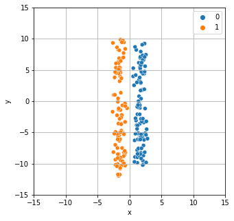

```python
plot_data_points(X, y, xlim=(-15, 15), ylim=(-15, 15))
```

Как видно, наши данные идеально разделяются прямой $x=0$

Функция $plot\_knn\_bound$ принимает на вход объекты $X$, метки классов $y$, метод нормализации признаков $scaler$, число соседей $n\_neighbors$ и границы рисунка $xlim$, $ylim$. Функция обучает $KNN$ классификатор с числом соседей $n\_neighbors$ и визуализирует разделяющую поверхность для классов, полученную с помощью обученного $KNN$ классификатора.

- Если вы не можете различить *выбранные нами цвета*, то измените список цветов в переменных cmap_light и cmap_bold. Актуальный список возможных цветов находится [здесь](https://matplotlib.org/stable/tutorials/colors/colormaps.html)

```python
from matplotlib.colors import ListedColormap
from sklearn import neighbors, datasets

def plot_knn_bound(X, y, scaler=None, n_neighbors=10, xlim=(-15, 15), ylim=(-20, 20)):
    # step size in the mesh
    h = 0.05

    # Create color maps
    cmap_light = ListedColormap(['C0', 'orange', 'cyan', 'green'][:np.unique(y).shape[0]])
    cmap_bold = ['C0', 'orange', 'c', 'darkgreen'][:np.unique(y).shape[0]]

    x_min, x_max = xlim
    y_min, y_max = ylim
    xx, yy = np.meshgrid(np.arange(x_min, x_max, h),
                         np.arange(y_min, y_max, h))
    grid = np.c_[xx.ravel(), yy.ravel()]

    X_scaled = X # if scaler is None
    if scaler is not None:
        grid = scaler.transform(grid)
        X_scaled = scaler.transform(X)

    # we create an instance of Neighbours Classifier and fit the data.
    clf = neighbors.KNeighborsClassifier(n_neighbors, algorithm='brute')
    clf.fit(X_scaled, y)

    Z = clf.predict(grid)

    # Put the result into a color plot
    Z = Z.reshape(xx.shape)
    plt.contourf(xx, yy, Z, cmap=cmap_light)

    # Plot also the training points
    sns.scatterplot(x=X[:, 0], y=X[:, 1], hue=y,
                    palette=cmap_bold, alpha=1.0, edgecolor="black")
    plt.xlabel('x')
    plt.ylabel('y')
    plt.title('Разделющие поверхности алгоритма {}-NN'.format(n_neighbors))
    plt.grid()
    plt.show()
```

Нарисуем разделющие поверхности $1$-$NN$ и $10$-$NN$

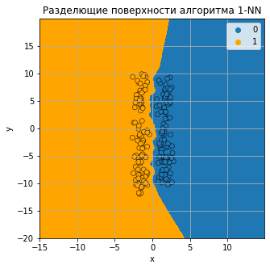

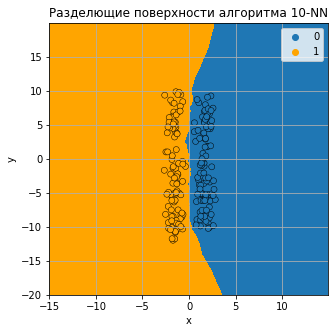

```python
plot_knn_bound(X, y, n_neighbors=1)
plot_knn_bound(X, y, n_neighbors=10)
```

**Задание 1.2** (кросс, 2 балла) Чем отличаются поверхности, полученные при числе соседей 1 и 10? Объясните, чем вызваны данные отличия

ОТВЕТ: При большем числе соседей более гладкая поверхность, при меньшем числе менее гладкая из-за переобучения

**Задание 1.3** (кросс, 3 балла) Объясните, почему наблюдается сильное отклоенние разделяющей поверхности от прямой $x=0$ при значениях $y < -10$ и $y > 10$. Дайте строгое математическое обоснование наблюдаемого явления

ОТВЕТ: Чем больше размерность и, как следствие, разброс значений признака тем сильнее отдельные объекты влияют на прогноз

Данную проблему может решить нормализация признакового пространства.

**Задание 1.4** (кросс, 1 балл) Начертите разделяющие поверхности для $KNN$, обученного на нормализованных признаках с помощью реализованных вами нормализаторов. Используйте функцию $plot\_knn\_bound$

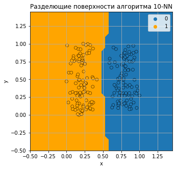

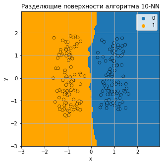

```python
from scalers import MinMaxScaler, StandardScaler

mm_scaler = MinMaxScaler()
mm_scaler.fit(X)
plot_knn_bound(mm_scaler.transform(X), y, n_neighbors=10, xlim=(-0.5, 1.5), ylim=(-0.5, 1.5))

std_scaler = StandardScaler()
std_scaler.fit(X)
plot_knn_bound(std_scaler.transform(X), y, n_neighbors=10, xlim=(-3, 3), ylim=(-3, 3))
```

**Задание 1.5** (кросс, 4 балла) Пусть дано произвольное число точек на плоскости. Представим, что каждая точка - это отдельный класс. Пусть на данной выборке был обучен $1-NN$ классификатор. Чем с геометрической точки зрения являются разделяющие поверхности этого классификатора? Требуется математически строго, однозначно и с полным обоснованием определить геометрическое место точек разделяющих поверхностей.

В качестве примера ниже представлена визуализация для четырех точек

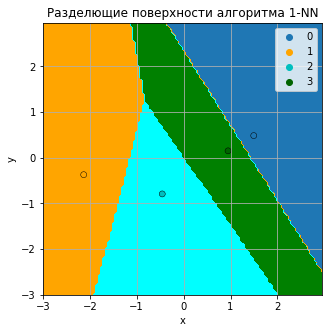

```python
X = np.random.randn(4, 2)
y = np.arange(4)
plot_knn_bound(X, y, n_neighbors=1, xlim=(-3, 3), ylim=(-3, 3))
```

ОТВЕТ: Между любымии двумя соседними точками разделяющая поверхность - серединный перпендикуляр к отрезку, их соединяющему. Это так, потому что именно на этой поверхности точки равноудалены от каждого из своих ближайших соседей.

# Часть 2. Кросс-валидация на задаче регрессии

При решении прикладных задач, как правило, доступна лишь обучающая выборка. Для того чтобы иметь возможность оценить качество модели на тестовой выборке, прибегают к методу, называемому кросс-валидация.  
Пусть зафиксирован некоторый набор параметров модели. В $KNN$ под параметрами могут пониматься число соседей, метрика близости $\rho$, стратегия выбора весов $w_i$. При кросс-валидации **обучающая** выборка делится на $n$ равных частей (folds). Затем обучаются $n$ моделей с заданными параметрами (у всех моделей параметры одинаковые и фиксированы) - $i$-ая модель обучается на всей обучающей выборке, кроме объектов, которые попали в $i$-ый фолд (out-of-fold). Затем измеряется качество $i$-ой модели на $i$-ом фолде. Так как он не участвовал в обучении этой модели, то полученная оценка качества модели будет являться корректной. Финальным значением метрики качества для модели с заданными параметрами является среднее полученных нами значений на $n$ фолдах.

*Подумайте, как в описанную выше схему корректно добавить обучение нормализаторов*

Принцип работы кросс-валидации схематично изображен на рисунке.

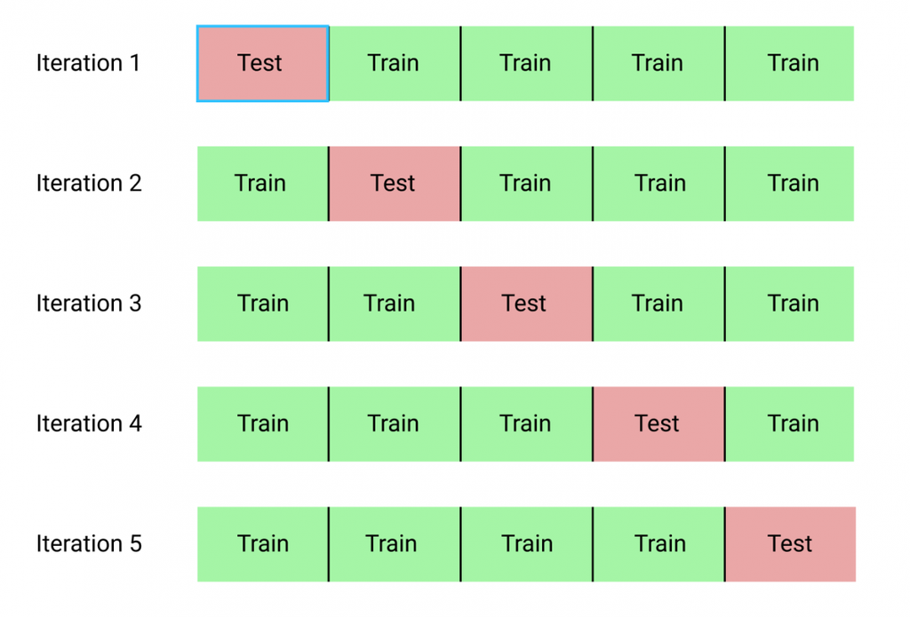

Небольшое видео объяснение о том, как работает кросс-валидация, можно посмотреть по [ссылке](https://www.youtube.com/watch?v=fSytzGwwBVw)

**Задание 2.1** (тест, 10 баллов) В модуле cross_val.py реализуйте функции

- $kfold\_split$, которая реализует генерацию индексов обучающей и валидационной выборок для кросс-валидации
- $knn\_cv\_score$, которая реализует кросс-валидацию для $KNN-$модели

Далее будем решать задачу предсказания цены дома в Калифорнии с помощью $KNN$-регрессии. В качестве метрики качества будем использовать $R^2-$score.

$R^2(y\_true, y\_predict) = 1 - \frac{\sum_{i=1}^{n} (y\_true_i - y\_predict_i)^2}{\sum_{i=1}^{n} (y\_true_i - E(y\_true_i))^2}$

```python
from sklearn.datasets import fetch_california_housing
from sklearn.model_selection import train_test_split
```

```python
X, y = fetch_california_housing(return_X_y=True)
```

**Задание 2.2** (кросс, 1 балл) Разбейте выборку на обучающую (75%) и тестовую (25%) с помощью функции $train\_test\_split$. Используйте параметр **random_state=42!** Не забудьте перемешать данные перед разбиением (см. параметры функции). Запустите кросс-валидацию на 3 фолдах с помощью реализованных вами функций $kfold\_split$, $knn\_cv\_score$. В качестве метрики используйте $r2\_score$. Параметры для перебора описаны ниже

```python
X_train, X_test, y_train, y_test = train_test_split(X, y, random_state=42, test_size=0.25, shuffle=True)
```

**После того, как вы локально реализовали и протестировали модуль cross_val.py, загрузите его в сессионное хранилище: нажмите знак папки слева, затем знак загрузки**

**Задание 2.3** (кросс, 3 балла) Какой наибольший $r2\_score$ удалось достичь на валидации? Какие закономерности вы видите? Обучите модель с наилучшими параметрами на всей обучающей выборке, измерьте $r2\_score$ на тестовой выборке.

```python
from sklearn.metrics import r2_score

parameters = {
    'n_neighbors': [1, 5, 10],
    'metrics': ['euclidean', 'cosine'],
    'weights': ['uniform', 'distance'],
    'normalizers': [(None, 'None'), (MinMaxScaler(), 'MinMax'), (StandardScaler(), 'Standard')]
}
score_function = r2_score
```

Выведите результаты кросс-валидации

```python
from cross_val import kfold_split, knn_cv_score

folds = kfold_split(X_train.shape[0], 3)
knn_cv_score(X_train, y_train, parameters, score_function, folds, neighbors.KNeighborsRegressor)
```

```
{('None', 1, 'euclidean', 'uniform'): -0.2698362539419594,
 ('None', 1, 'euclidean', 'distance'): -0.2698362539419594,
 ('None', 1, 'cosine', 'uniform'): 0.10527040776150857,
 ('None', 1, 'cosine', 'distance'): 0.1052704077615086,
 ('None', 5, 'euclidean', 'uniform'): 0.0977684191856583,
 ('None', 5, 'euclidean', 'distance'): 0.1199731657678866,
 ('None', 5, 'cosine', 'uniform'): 0.37805502479959713,
 ('None', 5, 'cosine', 'distance'): 0.3955985736693515,
 ('None', 10, 'euclidean', 'uniform'): 0.1157913069850766,
 ('None', 10, 'euclidean', 'distance'): 0.14310059566240177,
 ('None', 10, 'cosine', 'uniform'): 0.3775295488771868,
 ('None', 10, 'cosine', 'distance'): 0.40894335310524665,
 ('MinMax', 1, 'euclidean', 'uniform'): 0.5329368736058075,
 ('MinMax', 1, 'euclidean', 'distance'): 0.5329368736058075,
 ('MinMax', 1, 'cosine', 'uniform'): 0.4590323476108448,
 ('MinMax', 1, 'cosine', 'distance'): 0.4590323476108448,
 ('MinMax', 5, 'euclidean', 'uniform'): 0.6915621333110309,
 ('MinMax', 5, 'euclidean', 'distance'): 0.6964752425342953,
 ('MinMax', 5, 'cosine', 'uniform'): 0.6429483717302537,
 ('MinMax', 5, 'cosine', 'distance'): 0.6439729194747218,
 ('MinMax', 10, 'euclidean', 'uniform'): 0.6955574490923349,
 ('MinMax', 10, 'euclidean', 'distance'): 0.7035316821435433,
 ('MinMax', 10, 'cosine', 'uniform'): 0.6595874224717159,
 ('MinMax', 10, 'cosine', 'distance'): 0.6650747099452022,
 ('Standard', 1, 'euclidean', 'uniform'): 0.5139255367340351,
 ('Standard', 1, 'euclidean', 'distance'): 0.5139255367340351,
 ('Standard', 1, 'cosine', 'uniform'): 0.47958515234726945,
 ('Standard', 1, 'cosine', 'distance'): 0.47958515234726945,
 ('Standard', 5, 'euclidean', 'uniform'): 0.6793573692425973,
 ('Standard', 5, 'euclidean', 'distance'): 0.6834229913464561,
 ('Standard', 5, 'cosine', 'uniform'): 0.6639133943561187,
 ('Standard', 5, 'cosine', 'distance'): 0.666103286084983,
 ('Standard', 10, 'euclidean', 'uniform'): 0.6860471330995802,
 ('Standard', 10, 'euclidean', 'distance'): 0.691615057187545,
 ('Standard', 10, 'cosine', 'uniform'): 0.6765890035252449,
 ('Standard', 10, 'cosine', 'distance'): 0.6829471618912982}
```

ОТВЕТ: На валидации наибольший r2_score 0.7035316821435433 при ('MinMax', 10, 'euclidean', 'distance')

Обучите модель с лучшими по валидации параметрами на обучающей выборке

```python
X_train, X_test, y_train, y_test = train_test_split(X, y, random_state=42, test_size=0.25, shuffle=True)
```

```python
scl = MinMaxScaler()
scl.fit(X_train)
X_train = scl.transform(X_train)
X_test = scl.transform(X_test)

knn = neighbors.KNeighborsRegressor(n_neighbors=10, metric='euclidean', weights='distance')
knn.fit(X_train, y_train)
y_predict = knn.predict(X_test)

score_function(y_test, y_predict)
```

```
0.7117082182374788
```

# Часть 3. Работа с текстовыми данными

Далее будем решать задачу классификации новостного текста к одному из 20 классов, каждый класс соответствует определенной новостной тематике. В качестве метрики качества будем использовать $accuracy\_score$. Accuracy - это доля верно классифицированных объектов, среди всех объектов выборки.

```python
from sklearn.datasets import fetch_20newsgroups
from sklearn.feature_extraction.text import CountVectorizer, TfidfVectorizer
```

```python
X_train, y_train = fetch_20newsgroups(subset='train', return_X_y=True, random_state=42)
X_test, y_test = fetch_20newsgroups(subset='test', return_X_y=True, random_state=42)
```

```python
print(X_train[0])
```

```
From: lerxst@wam.umd.edu (where's my thing)
Subject: WHAT car is this!?
Nntp-Posting-Host: rac3.wam.umd.edu
Organization: University of Maryland, College Park
Lines: 15

 I was wondering if anyone out there could enlighten me on this car I saw
the other day. It was a 2-door sports car, looked to be from the late 60s/
early 70s. It was called a Bricklin. The doors were really small. In addition,
the front bumper was separate from the rest of the body. This is
all I know. If anyone can tellme a model name, engine specs, years
of production, where this car is made, history, or whatever info you
have on this funky looking car, please e-mail.

Thanks,
- IL
   ---- brought to you by your neighborhood Lerxst ----
```

```python
X_train = np.array(X_train, dtype=object)
```

```python
X_test = np.array(X_test, dtype=object)
```

```python
y_train = np.array(y_train)
y_test = np.array(y_test)
```

Как мы видим, объектами обучающей выборки являются тексты. Сырые текстовые данные не могут служить обучающими примерами для алгоритма $KNN$. Перед использованием $KNN$ текстовые данные переменной длины необходимо отобразить в метрическое пространство фиксированной размерности.

Работа с текстовыми данными проходит в несколько этапов.

- **Токенизация.** Текстовая строка делится на токены. Как правило, в качестве токенов выступают отдельные слова и знаки препинания.
- **Нормализация.** Приведение к нижнему регистру, удаление стоп-слов, удаление пунктуации, удаление редких и частотных слов и т.д.
- **Векторизация.** Фиксируется словарь токенов $V$ по **обучающей** выборке. Текст представлется в виде вектора длиной $|V|$, где каждый признак есть функция от частоты встречаемости токена в тексте и в обучающей выборке.

В данном задании будет использовано два вида векторизации. Первый, $CountVectorizer$, сопоставляет каждому токену частоту встречаемости этого токена в тексте документа. Второй, $TfidfVectorizer$, сопоставляет каждому токену частоту встречаемости этого токена в тексте документа умноженную на величину обратно пропорциональную частоте встречаемости токена во всех документах **обучающей** выборки. Подробне про $tf-idf$ можно прочитать [здесь](https://ru.wikipedia.org/wiki/TF-IDF).

В sklearn все векторизаторы автоматически токенизируют текст и приводят его к нижнему регистру. Параметры $max\_df$ и $min\_df$ позволяют убрать из словаря наиболее частые и наиболее редкие токены. Параметр $stop\_words$ позволяет убрать из словаря стоп-слова (малоинформативные слова для данного языка, например, союзы).

```python
count_vec = CountVectorizer(max_df=0.8, min_df=10, stop_words='english')
tf_idf = TfidfVectorizer(max_df=0.8, min_df=10, stop_words='english')
```

**Задание 3.1** (кросс, 2 балла) Найдите оптимальные параметры обучения модели. Осуществлять перебор параметров следует по заданной ниже сетке. Используйте реализованные вами функции $kfold\_split$, $knn\_cv\_score$. В качестве метрики используйте $accuracy\_score$. 3х фолдов для кросс-валидации будет достаточно.

```python
from sklearn.metrics import accuracy_score

parameters = {
    'n_neighbors': [i for i in range(1, 11)],
    'metrics': ['euclidean', 'cosine'],
    'weights': ['uniform', 'distance'],
    'normalizers': [(count_vec, 'CountVectorizer'), (tf_idf, 'TfidfVectorizer')]
}
```

Если вы все сделаете правильно, то запущенная вами кросс-валидация будет работать примерно 7 минут. Дождитесь ее завершения, не закрывайте и не перезагружайте этот colab ноутбук.

```python
folds = kfold_split(X_train.shape[0], 3)
res_7_min = knn_cv_score(X_train, y_train, parameters, accuracy_score, folds, neighbors.KNeighborsClassifier)
```

```python
res_7_min
```

```
{('CountVectorizer', 1, 'euclidean', 'uniform'): 0.5788394464311978,
 ('CountVectorizer', 1, 'euclidean', 'distance'): 0.5788394464311978,
 ('CountVectorizer', 1, 'cosine', 'uniform'): 0.7664838188107246,
 ('CountVectorizer', 1, 'cosine', 'distance'): 0.7664838188107246,
 ('CountVectorizer', 2, 'euclidean', 'uniform'): 0.47719622945252316,
 ('CountVectorizer', 2, 'euclidean', 'distance'): 0.5791930688322138,
 ('CountVectorizer', 2, 'cosine', 'uniform'): 0.7119503468217899,
 ('CountVectorizer', 2, 'cosine', 'distance'): 0.7664838188107246,
 ('CountVectorizer', 3, 'euclidean', 'uniform'): 0.46897606700462563,
 ('CountVectorizer', 3, 'euclidean', 'distance'): 0.5679678893049869,
 ('CountVectorizer', 3, 'cosine', 'uniform'): 0.7189325496554747,
 ('CountVectorizer', 3, 'cosine', 'distance'): 0.7613573016675136,
 ('CountVectorizer', 4, 'euclidean', 'uniform'): 0.4699484231534232,
 ('CountVectorizer', 4, 'euclidean', 'distance'): 0.5582455698307458,
 ('CountVectorizer', 4, 'cosine', 'uniform'): 0.7185789506886802,
 ('CountVectorizer', 4, 'cosine', 'distance'): 0.7621527763131389,
 ('CountVectorizer', 5, 'euclidean', 'uniform'): 0.46729644261957476,
 ('CountVectorizer', 5, 'euclidean', 'distance'): 0.5412755846627332,
 ('CountVectorizer', 5, 'cosine', 'uniform'): 0.7214072034359443,
 ('CountVectorizer', 5, 'cosine', 'distance'): 0.7596783334406619,
 ('CountVectorizer', 6, 'euclidean', 'uniform'): 0.46208143785633493,
 ('CountVectorizer', 6, 'euclidean', 'distance'): 0.5322597132269963,
 ('CountVectorizer', 6, 'cosine', 'uniform'): 0.7177835697799405,
 ('CountVectorizer', 6, 'cosine', 'distance'): 0.7573800690447152,
 ('CountVectorizer', 7, 'euclidean', 'uniform'): 0.4561590945541775,
 ('CountVectorizer', 7, 'euclidean', 'distance'): 0.5197969959015422,
 ('CountVectorizer', 7, 'cosine', 'uniform'): 0.714336536416452,
 ('CountVectorizer', 7, 'cosine', 'distance'): 0.7547287212348448,
 ('CountVectorizer', 8, 'euclidean', 'uniform'): 0.4511207135176744,
 ('CountVectorizer', 8, 'euclidean', 'distance'): 0.5134335736840817,
 ('CountVectorizer', 8, 'cosine', 'uniform'): 0.7117733715817322,
 ('CountVectorizer', 8, 'cosine', 'distance'): 0.7546402336148158,
 ('CountVectorizer', 9, 'euclidean', 'uniform'): 0.4411328608806824,
 ('CountVectorizer', 9, 'euclidean', 'distance'): 0.5054789678331566,
 ('CountVectorizer', 9, 'cosine', 'uniform'): 0.7107129261946697,
 ('CountVectorizer', 9, 'cosine', 'distance'): 0.752518897590484,
 ('CountVectorizer', 10, 'euclidean', 'uniform'): 0.43503401102289535,
 ('CountVectorizer', 10, 'euclidean', 'distance'): 0.5007062371305114,
 ('CountVectorizer', 10, 'cosine', 'uniform'): 0.7080610628319283,
 ('CountVectorizer', 10, 'cosine', 'distance'): 0.7490715595821172,
```

[output cut: 25 more lines]

```
 ('TfidfVectorizer', 7, 'euclidean', 'distance'): 0.7682512980918262,
 ('TfidfVectorizer', 7, 'cosine', 'uniform'): 0.743768559317498,
 ('TfidfVectorizer', 7, 'cosine', 'distance'): 0.7792995258132166,
 ('TfidfVectorizer', 8, 'euclidean', 'uniform'): 0.7434150072191462,
 ('TfidfVectorizer', 8, 'euclidean', 'distance'): 0.768427851515899,
 ('TfidfVectorizer', 8, 'cosine', 'uniform'): 0.7434150072191462,
 ('TfidfVectorizer', 8, 'cosine', 'distance'): 0.7797413311893834,
 ('TfidfVectorizer', 9, 'euclidean', 'uniform'): 0.7434149369164821,
 ('TfidfVectorizer', 9, 'euclidean', 'distance'): 0.7662183793848593,
 ('TfidfVectorizer', 9, 'cosine', 'uniform'): 0.7434149369164821,
 ('TfidfVectorizer', 9, 'cosine', 'distance'): 0.7786807451969923,
 ('TfidfVectorizer', 10, 'euclidean', 'uniform'): 0.7396142342835348,
 ('TfidfVectorizer', 10, 'euclidean', 'distance'): 0.7644505720246576,
 ('TfidfVectorizer', 10, 'cosine', 'uniform'): 0.7396142342835348,
 ('TfidfVectorizer', 10, 'cosine', 'distance'): 0.7768247782958616}
```

**Задание 3.2** (кросс, 2 балла) Какой метод предобработки данных в среднем дает наилучший результат? Почему?

```python
tfid = []
count = []
for i in res_7_min:
  if i[0] == 'TfidfVectorizer':
    tfid.append(res_7_min[i])
  else:
    count.append(res_7_min[i])
print('tfid', sum(tfid) / len(tfid))
print('count', sum(count) / len(count))
```

```
tfid 0.7605066798545091
count 0.6222374409914588
```

Способ борьбы с этой проблемой - использовать TF-IDF. Что делает TF-IDF, так это уравновешивает частоту термина (как часто слово появляется в документе) с его обратной частотой документа (как часто термин появляется во всех документах в наборе данных).). Это означает, что такие слова, как “a” и “the”, будут иметь очень низкие оценки, поскольку они будут появляться во всех документах в вашем наборе. Более редкие слова, такие как, например, “машинное обучение”, будут очень распространены всего в нескольких документах, в которых говорится о компьютерных науках или искусственном интеллекте. TF-IDF даст более высокие оценки этим словам, и, таким образом, это будут те слова, которые модель считает важными и пытается выучить.

**Задание 3.3** (кросс, 2 балла) Какая метрика близости позволяет в среднем достичь наилучшее качество? Почему?

```python
cosine = []
euclidean = []
for i in res_7_min:
  if i[2] == 'cosine':
    cosine.append(res_7_min[i])
  else:
    euclidean.append(res_7_min[i])
print('cosine', sum(cosine) / len(cosine))
print('euclidean', sum(euclidean) / len(euclidean))
```

```
cosine 0.7508174905107807
euclidean 0.631926630335187
```

ОТВЕТ: Косинусная метрика позволяет в среднем достичь наилучшее качество. Это так, потому что косинусная метрика показывает близость текстов по смыслу, не реагирует на увелечение длины текста путём повтора слов (она реагирует на угол между векторами, а не на их длину)

**Задание 3.4** (кросс, 2 балла) Начертите график зависимости метрики качества от числа соседей. Метрику следует усреднить по всем параматрам, кроме числа соседей. Сделайте выводы о наблюдаемых зависимостях (возможно будет полезным ознакомиться с названиями классов)

```python
import matplotlib
import matplotlib.pyplot as plt

#отображение графиков в ноутбуке
%matplotlib inline
```

```python
def mean(dict, num):
  ans = []
  for i in dict:
    if i[1] == num:
      ans.append(dict[i])
  return sum(ans) / len(ans)
```

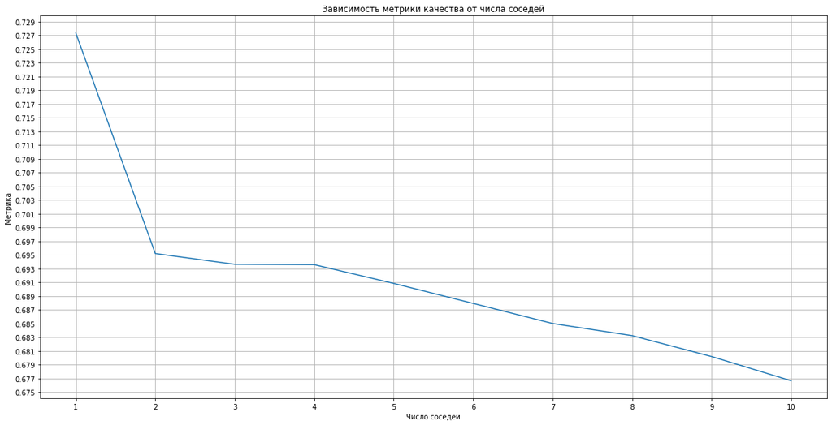

```python
x = [i+1 for i in range(10)]
y = [mean(res_7_min, i+1) for i in range(10)]

plt.figure(figsize=(20,10))
plt.title('Зависимость метрики качества от числа соседей')
plt.plot(x, y)
plt.grid(True)
plt.xticks(range(1, 11))
plt.yticks([0.675 + i*0.001 for i in range(0, 56, 2)])
plt.xlabel('Число соседей')
plt.ylabel('Метрика')
plt.show()
```

ОТВЕТ: Чем больше соседей, тем меньше значение метрики

**Задание 3.5** (кросс, 3 балла) Оцените точность вашей лучшей модели на тестовой части датасета. Отличается ли оно от качества, полученного на кросс-валидации? Почему?

```python
list(res_7_min.keys())[list(res_7_min.values()).index(max(res_7_min.values()))]
```

```
('TfidfVectorizer', 4, 'cosine', 'distance')
```

```python
tf_idf.fit(X_train)
X_train = tf_idf.transform(X_train)
X_test = tf_idf.transform(X_test)

knn = neighbors.KNeighborsClassifier(n_neighbors=4, metric='cosine', weights='distance')
knn.fit(X_train, y_train)
y_predict = knn.predict(X_test)

accuracy_score(y_test, y_predict)
```

```
0.6688794476898566
```

ОТВЕТ: Отличается, оно меньше, значит, в тестовой выборке может быть информация, которую мы не учитываем